# Blocking and Clustering

Shikhar Singh

September 16, 2026

# Agenda

### 1. Block V. Cluster Randomization

### 2. Estimation With Blocking

- Difference-in-Means
- Standard Error
- Impact on Sampling Variability

### 3. Estimation With Clustering

- Difference-in-Means
- Standard Error
- Impact on Sampling Variability

# Types of Randomization

**Blocking:** Block random assignment refers to a procedure whereby subjects are partitioned into subgroups (called blocks or strata), and complete random assignment occurs within each block. In effect, block randomization creates a series of miniature experiments, one per block.(FEDAI:71)

**Empirical Example:** Consider a data set of 1,000 observations, split into two “blocks”: $X_1 = 1$ and $X_1=0$.

```r
library(tidyverse)

set.seed(092025)

dat1 <- tibble(
  Y0 = runif(1000, min = -1, max = 1),
  Y1 = Y0 + rnorm(1000, mean = 5, sd = 4),
  X1 = as.numeric(Y0 >= 0),
  X2 = randomizr::complete_ra(N = 1000, m = 500),
  C1 = case_when(
    Y0 <= -0.75 ~ 1,
    (Y0 > -0.75) & (Y0 <= -0.5) ~ 2,
    (Y0 > -0.5) & (Y0 <= -0.25) ~ 3,
    (Y0 > -0.25) & (Y0 <= 0) ~ 4,
    (Y0 > 0) & (Y0 <= 0.25) ~ 5,
    (Y0 > 0.25) & (Y0 <= 0.5) ~ 6,
    (Y0 > 0.5) & (Y0 <= 0.75) ~ 7,
    (Y0 > 0.75) ~ 8,
  ),
  C2 = sample(
    x = c(1:8),
    size = 1000,
    replace = T,
    prob = rep(1 / 8, 8)
  )
)
```

Block $X_1=0$ has 484 subjects, Block $X_1=1$ has 516 observations. We conduct block randomization using the function `block_ra`, assigning exactly 242 observations in the first block and 258 observations in the second block to treatment. We compare block randomization to simple ($p_{Z=1} = 0.5$) and complete random assignments ($m=500$):

```r
library(randomizr)
library(kableExtra)

dat1 <- dat1 %>%
  mutate(
    Z_blocked = block_ra(blocks = X1, block_m = c(242, 258)),
    Z_complete = complete_ra(N = 1000, m = 500),
    Z_simple = simple_ra(N = 1000, prob = 0.5)
  )

table(dat1$Z_blocked, dat1$X1) %>%
  kbl(. ,
      caption = "Block Randomization",
      col.names = c("X1=0","X1=1"),
      caption.above = TRUE) %>%
  kable_classic(full_width = F)
```

Block Randomization

|  | X1=0 | X1=1 |
| --- | --- | --- |
| 0 | 242 | 258 |
| 1 | 242 | 258 |

```r
table(dat1$Z_complete, dat1$X1) %>%
  kbl(. ,
      caption = "Complete Random Assignment",
      col.names = c("X1=0","X1=1"),
      caption.above = TRUE) %>%
  kable_classic(full_width = F)
```

Complete Random Assignment

|  | X1=0 | X1=1 |
| --- | --- | --- |
| 0 | 249 | 251 |
| 1 | 235 | 265 |

```r
table(dat1$Z_simple, dat1$X1) %>%
  kbl(. ,
      caption = "Simple Random Assignment",
      col.names = c("X1=0","X1=1"),
      caption.above = TRUE) %>%
  kable_classic(full_width = F)
```

Simple Random Assignment

|  | X1=0 | X1=1 |
| --- | --- | --- |
| 0 | 222 | 248 |
| 1 | 262 | 268 |

**Clustering:** Cluster random assignment implies that all subjects in the same cluster are placed as a group into either the treatment or control condition. (FEDAI:80)

**Empirical Example:** Consider the same data set of 1,000 observations. Say we divide subjects into eight clusters, $C_1 = \{1,2,3,4,5,6,7,8\}$. We randomly assign *four* of *eight* clusters to treatment, and the remaining to control. All the observations within a cluster are assigned to the same experimental condition.

```r
dat1 <- dat1 %>%
  mutate(
    Z_cluster = cluster_ra(clusters = C1, m = 4)
  )

table(dat1$Z_cluster, dat1$C1) %>%
  kbl(. ,
      caption = "Cluster Randomization",
      caption.above = TRUE) %>%
  add_header_above(c(" " = 1, "Clusters" = 8)) %>%
  kable_classic(full_width = F)
```

Cluster Randomization

|  | Clusters 1 | Clusters 2 | Clusters 3 | Clusters 4 | Clusters 5 | Clusters 6 | Clusters 7 | Clusters 8 |
| --- | --- | --- | --- | --- | --- | --- | --- | --- |
| 0 | 120 | 0 | 122 | 0 | 0 | 124 | 0 | 129 |
| 1 | 0 | 115 | 0 | 127 | 119 | 0 | 144 | 0 |

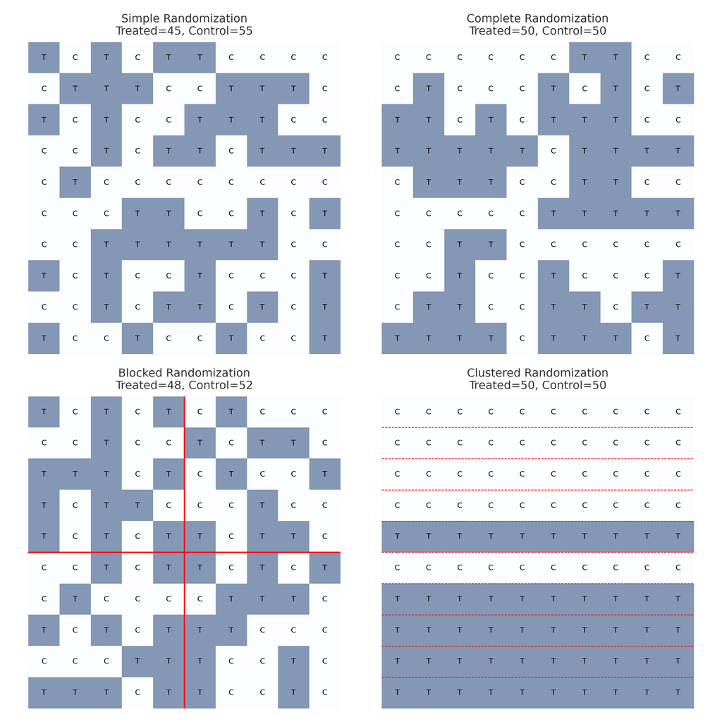

Figure 1: Types of Randomization

# Estimation With Blocking

## Estimator

> The overall ATE when there are $j$ blocks, each with $n_j$ subjects is: $\sum_{j=1}^J \frac{n_j}{N}\text{ATE}_j$ (where $\frac{n_j}{N}$ is a weight that gives the proportion of all subjects in that particular block).

## Standard Error

> The overall SE when there are $j$ blocks, each with $n_j$ subjects is: $\sqrt{\sum_{j=1}^J (\frac{n_j}{N})^2\text{SE}_j^2}$.

**Practice:** Use the above formula to calculate the overall ATE and SE for the data provided in Table 3.4 (FEDAI:76).

## In-Code

Here are a few ways you can estimate the overall and block-level ATEs in `R`

**Strategy 1:** Use group_by and summarise:

```r
# Pre-Step: Apply switching equation to get observed outcomes (not needed if youre working with actual data)

dat1 <- dat1 %>%
  mutate(Y = Y1 * Z_blocked + Y0 * (1 - Z_blocked))

# Use Group-By to Get Block Level ATEs
block_DIM <- dat1 %>%
  group_by(X1) %>%
  summarise(DIM = mean(Y[Z_blocked == 1]) - mean(Y[Z_blocked == 0]), Nj = n())

kbl(block_DIM,
    caption = "Block-Level ATE estimates") %>%
  kable_classic(full_width = F)
```

Block-Level ATE estimates

| X1 | DIM | Nj |
| --- | --- | --- |
| 0 | 4.836956 | 484 |
| 1 | 5.006230 | 516 |

```r
# Use Summarize to get Overall ATE

ate <- block_DIM %>%
  summarise(estimate = sum(DIM * (Nj / sum(Nj))))

kbl(ate, caption = "Overall ATE") %>%
  kable_classic(full_width = F)
```

Overall ATE

| estimate |
| --- |
| 4.924302 |

**Strategy 2:** Use the blocks specification in `difference_in_means` or control for blocks using the fixed-effects option in `lm_robust`:

```r
library(estimatr)

# EITHER SPECIFY BLOCKS
m1 <- difference_in_means(Y ~ Z_blocked, blocks = X1, data = dat1)

# OR CONTROL FOR THEM USING FIXED EFFECTS
# Note: Use IPW if probability of assignment varies by block

m2 <- lm_robust(Y ~ Z_blocked + X1, data = dat1)

texreg::htmlreg(
  list(m1, m2),
  include.ci = FALSE,
  booktabs = TRUE,
  custom.model.names = c("DIM","LM ROBUST"),
  caption = "Overall ATE, using estimatr",
  caption.above = TRUE
)
```

Overall ATE, using estimatr

|  | DIM | LM ROBUST |
| --- | --- | --- |
| Z_blocked | 4.92*** | 4.92*** |
|  | (0.17) | (0.17) |
| (Intercept) |  | -0.54*** |
|  |  | (0.09) |
| X1 |  | 1.08*** |
|  |  | (0.17) |
| DF | 996.00 |  |
| nobs | 1000 |  |
| nblocks | 2 |  |
| nclusters | 0 |  |
| condition2 | 1 |  |
| condition1 | 0 |  |
| R<sup>2</sup> |  | 0.47 |
| Adj. R<sup>2</sup> |  | 0.47 |
| Num. obs. |  | 1000 |
| RMSE |  | 2.70 |

***p < 0.001; **p < 0.01; *p < 0.05

**Note:** If the probability of treatment assignment is different for blocks, pooling observations and calculating the ATE will give biased estimates. We need to use inverse-probability weighting, where the weights are the probability of being assigned to the condition in which the observation is.

## Sampling Variability

> Blocking typically reduces sampling variability and improves precision.

**Intuition:** When blocks are formed using covariates (background variables) that are strongly predictive of the outcome, subjects with similar potential outcomes will be in the same block. Blocking reduces the number of possible randomizations, especially “extreme” cases that produce large variances in the treatment effect estimate.

Blocking and Sampling Variability

| Block | Y1 | Y0 | d_complete | d_block |
| --- | --- | --- | --- | --- |
| City | 4 | 5 | 1 | 1 |
| City | 3 | 4 | 1 | 0 |
| Rural | 14 | 10 | 0 | 1 |
| Rural | 16 | 12 | 0 | 0 |

For example, in the above data set the true ATE is 1.5: $-1$ for urban citizens and $+4$ for rural citizens. If we use complete random assignment, there is a possible assignment in which all the treated subjects are in the city and all the untreated subjects are in rural areas ($\widehat{ATE} = -7.5$); or all the untreated subjects are in the city and all the treated subjects are in rural areas ($\widehat{ATE} = 10.5$). These “extreme” randomizations produce extreme estimates that increase sampling variability. Blocking prevents this possibility by conducting to two mini-experiments: one in the city, another in rural areas. With blocking, we get two similar estimates. For example, in the city block we could get either $\widehat{ATE_{\text{city}}} = 0$ or $-2$; and for the rural block we could get either $\widehat{ATE_{\text{rural}}} = 2$ or $6$.

**Unpredictive Covariates:** Blocking on unpredictive covariates does not reduce sampling variability. Its basically as good as not blocking!

**Simple Random Assignment:** Say you create blocks, then conduct simple random assignment. That is effectively “unblocking” because simple randomization can produce assignments in which all (or most) of the units in a block are assigned to one condition.

**Heterogeneous Effects:** By creating mini-experiments, blocking also “ensures that certain subgroups are available for separate analysis” (FEDAI:73). For example, if we want to analyze the effect of treatment in the city (or rural areas), blocking will always give us a treatment-control comparison for cities (or rural areas). In complete or simple random assignment it is possible under some “extreme” assignments that we do not get treatment-control comparisons within each block.

# Estimation With Clustering

When data are clustered, you will estimate the difference-in-means using the pooled data. However, your standard errors will be computed differently.

**Practice:** In Table 3.6 (FEDAI:81), calculate the average treatment effect by taking an average of $Y_i(1)$ (column 4) and $Y_i(0)$ (column 3). Repeat the exercise by calculating the average of cluster-level potential outcomes $Y_j(1)$ (column 6) and $Y_j(0)$ (column 5). These will be the same.

## Standard Error

> The true standard error when there are $k$ clusters is: $\sqrt{\frac{1}{k-1}\{\frac{m}{N-m}Var[\overline{Y_j(0)}] + \frac{N-m}{m}Var[\overline{Y_j(1)}] + 2Cov[\overline{Y_j(0)},\overline{Y_j(1)}]\}}$ where ($\overline{Y_j(0)}$ is the average untreated potential outcome in cluster $j$, and $\overline{Y_j(1)}$ is the average treated potential outcome in cluster $j$).

Note how this equation, (Equation 3.22) is similar in structure to the true standard error equation we discussed in Chapter III (Equation 3.4):

Equation 3.4: $\sqrt{\frac{1}{N-1}\{\frac{m}{N-m}Var[Y_i(0)] + \frac{N-m}{m}Var[Y_i(1)] + 2Cov[Y_i(0),Y_i(1)]\}}$

Equation 3.22: $\sqrt{\frac{1}{k-1}\{\frac{m}{N-m}Var[\overline{Y_j(0)}] + \frac{N-m}{m}Var[\overline{Y_j(1)}] + 2Cov[\overline{Y_j(0)},\overline{Y_j(1)}]\}}$

The difference between these equations is that $\frac{1}{N-1}$ is replaced by $\frac{1}{k-1}$; and unit-level potential outcomes ($Y_i(1)$ and $Y_i(0)$) are replaced by cluster-level average potential outcomes ($\overline{Y_j(1)}$ and $\overline{Y_j(0)}$).

> To estimate the standard error when there are $k$ clusters we use Equation 3.23: $\sqrt{\frac{N \cdot \widehat{Var}(\overline{Y_j(0)})}{k(N-m)} + \frac{N \cdot \widehat{Var}(\overline{Y_j(1)})}{km}}$

## Sampling Variability

> Clustering typically increases sampling variability and reduces precision.

**Intuition 1:** Equation 3.22 will be larger than Equation 3.4 because we divide by a smaller number, $k < N$ (there are fewer clusters than total observations)

**Intuition 2:** Equation 3.22 will be larger when clusters are homogeneous, compared to when they are heterogeneous.

In equation 3.22, $Var[\overline{Y_j(0)}]$ is the variance in the cluster-level average untreated potential outcome, and $Var[\overline{Y_j(1)}]$ is the variance in the cluster-level average treated potential outcome. When clusters are very homogeneous, potential outcomes are very similar within a cluster and very different across clusters. As a result, the variance in cluster averages or $Var(\cdot)$ is large. In contrast, when clusters are very heterogeneous, potential outcomes are very different within a cluster but very similar, on average, across clusters. This means cluster averages are very similar, and the variance in those values or $Var(\cdot)$ is small.

### Example

To illustrate this point, lets conduct simulations in which we compare the sampling distribution when clusters are homogeneous ($C_1$) and when observations are randomly assigned to clusters ($C_2$), implying that clusters are heterogeneous.

**Step 1:** Lets specify two types of cluster random assignments - cluster random assignment with $C_1$ (exactly $m=4$ of $N=8$ clusters are assigned to treatment), and similarly with $C_2$ (exactly four of the clusters, $m=4$, are assigned to treatment).

**Note:** In `randomizr`, when you specify a cluster, `m` should indicate the *number of clusters* (not the number of subjects) to be assigned to the treatment condition. You will notice that if clusters are of unequal size, then the actual number of treated subjects will vary, depending on which clusters are assigned to the treatment condition.

```r
library(randomizr)

c1_ra_declaration = declare_ra(N = nrow(dat1),
                               clusters = dat1$C1,
                               m = 4)

c2_ra_declaration = declare_ra(N = nrow(dat2),
                               clusters = dat1$C2,
                               m = 4)
```

**Step 2:** Using simulations, I recover the sampling distribution of the average treatment effect under the two cluster assignments. Note that we use `difference_in_means` from the `estimatr` package and we specify `clusters`.

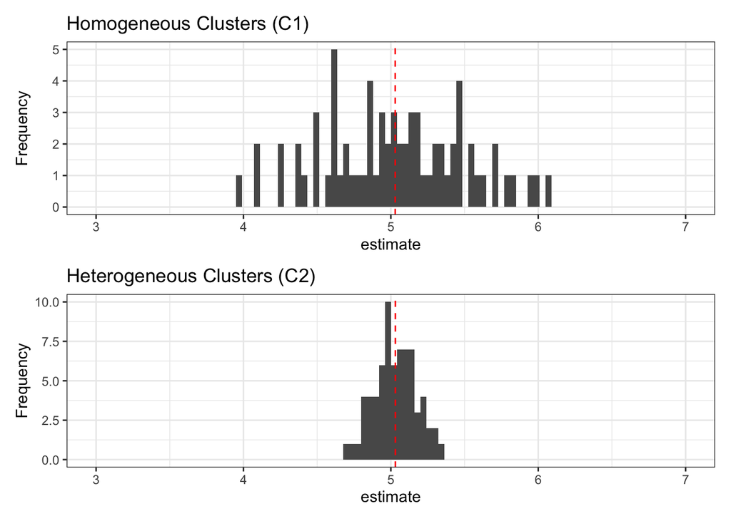

```r
library(estimatr)

# When C1 is the clustering variable

D_c1_ra <- obtain_permutation_matrix(c1_ra_declaration)

ests_c1_ra <- c()

for(i in 1:ncol(D_c1_ra)) {
  dat_temp <- dat1 %>%
    mutate(d_temp = D_c1_ra[, i],
           y_temp = d_temp * Y1 + (1 - d_temp) * Y0)
  estimate = tidy(difference_in_means(y_temp ~ d_temp, clusters = C1, data = dat_temp))
  ests_c1_ra = bind_rows(ests_c1_ra, estimate)
}

# When C2 is the clustering variable

D_c2_ra <- obtain_permutation_matrix(c2_ra_declaration)

ests_c2_ra <- c()

for(i in 1:ncol(D_c2_ra)) {
  dat_temp <- dat1 %>%
    mutate(d_temp = D_c2_ra[, i],
           y_temp = d_temp * Y1 + (1 - d_temp) * Y0)
  estimate = tidy(difference_in_means(y_temp ~ d_temp, clusters = C2, data = dat_temp))
  ests_c2_ra = bind_rows(ests_c2_ra, estimate)
}

# Make a figure to compare the two sampling distributions


fig1 <- ggplot(data = ests_c1_ra, aes(x = estimate)) +
  geom_histogram(bins = 100) +
  geom_vline(
    xintercept = mean(ests_c1_ra$estimate),
    linetype = "dashed",
    color = "red"
  ) +
  ylab("Frequency") +
  xlim(c(3, 7)) +
  ggtitle("Homogeneous Clusters (C1)") +
  theme_bw()


fig2 <- ggplot(data = ests_c2_ra, aes(x = estimate)) +
  geom_histogram(bins = 100) +
  geom_vline(
    xintercept = mean(ests_c2_ra$estimate),
    linetype = "dashed",
    color = "red"
  ) +
  ylab("Frequency") +
  xlim(c(3, 7)) +
  ggtitle("Heterogeneous Clusters (C2)") +
  theme_bw()

library(patchwork)

fig1 / fig2
```